# Risk Factor Analysis

## Outcome Variable

**Outcome Variable:** ever_stunted

## Predictor Variables

**Intervention Variable:** birthlen

**Adjustment Set:**

- arm
- sex
- W_mage
- meducyrs
- feducyrs
- vagbrth
- single
- brthmon
- W_parity
- delta_W_mage
- delta_meducyrs
- delta_feducyrs
- delta_vagbrth
- delta_single
- delta_brthmon
- delta_W_parity

## Stratifying Variables

The analysis was stratified on these variable(s):

- agecat
- studyid
- country

## Data Summary

| agecat | studyid | country | birthlen | ever_stunted | n_cell | n |
| --- | --- | --- | --- | --- | --- | --- |
| 0-24 months (no birth st.) | CMC-V-BCS-2002 | INDIA | >=50 cm | 0 | 4 | 86 |
| 0-24 months (no birth st.) | CMC-V-BCS-2002 | INDIA | >=50 cm | 1 | 12 | 86 |
| 0-24 months (no birth st.) | CMC-V-BCS-2002 | INDIA | <48 cm | 0 | 2 | 86 |
| 0-24 months (no birth st.) | CMC-V-BCS-2002 | INDIA | <48 cm | 1 | 28 | 86 |
| 0-24 months (no birth st.) | CMC-V-BCS-2002 | INDIA | [48-50) cm | 0 | 5 | 86 |
| 0-24 months (no birth st.) | CMC-V-BCS-2002 | INDIA | [48-50) cm | 1 | 35 | 86 |
| 0-24 months (no birth st.) | CMIN | BANGLADESH | >=50 cm | 0 | 2 | 17 |
| 0-24 months (no birth st.) | CMIN | BANGLADESH | >=50 cm | 1 | 0 | 17 |
| 0-24 months (no birth st.) | CMIN | BANGLADESH | <48 cm | 0 | 7 | 17 |
| 0-24 months (no birth st.) | CMIN | BANGLADESH | <48 cm | 1 | 3 | 17 |
| 0-24 months (no birth st.) | CMIN | BANGLADESH | [48-50) cm | 0 | 1 | 17 |
| 0-24 months (no birth st.) | CMIN | BANGLADESH | [48-50) cm | 1 | 4 | 17 |
| 0-24 months (no birth st.) | COHORTS | GUATEMALA | >=50 cm | 0 | 174 | 802 |
| 0-24 months (no birth st.) | COHORTS | GUATEMALA | >=50 cm | 1 | 263 | 802 |
| 0-24 months (no birth st.) | COHORTS | GUATEMALA | <48 cm | 0 | 13 | 802 |
| 0-24 months (no birth st.) | COHORTS | GUATEMALA | <48 cm | 1 | 100 | 802 |
| 0-24 months (no birth st.) | COHORTS | GUATEMALA | [48-50) cm | 0 | 47 | 802 |
| 0-24 months (no birth st.) | COHORTS | GUATEMALA | [48-50) cm | 1 | 205 | 802 |
| 0-24 months (no birth st.) | COHORTS | INDIA | >=50 cm | 0 | 1267 | 5848 |
| 0-24 months (no birth st.) | COHORTS | INDIA | >=50 cm | 1 | 159 | 5848 |
| 0-24 months (no birth st.) | COHORTS | INDIA | <48 cm | 0 | 1082 | 5848 |
| 0-24 months (no birth st.) | COHORTS | INDIA | <48 cm | 1 | 900 | 5848 |
| 0-24 months (no birth st.) | COHORTS | INDIA | [48-50) cm | 0 | 1822 | 5848 |
| 0-24 months (no birth st.) | COHORTS | INDIA | [48-50) cm | 1 | 618 | 5848 |
| 0-24 months (no birth st.) | COHORTS | PHILIPPINES | >=50 cm | 0 | 538 | 2863 |
| 0-24 months (no birth st.) | COHORTS | PHILIPPINES | >=50 cm | 1 | 591 | 2863 |
| 0-24 months (no birth st.) | COHORTS | PHILIPPINES | <48 cm | 0 | 88 | 2863 |
| 0-24 months (no birth st.) | COHORTS | PHILIPPINES | <48 cm | 1 | 487 | 2863 |
| 0-24 months (no birth st.) | COHORTS | PHILIPPINES | [48-50) cm | 0 | 327 | 2863 |
| 0-24 months (no birth st.) | COHORTS | PHILIPPINES | [48-50) cm | 1 | 832 | 2863 |

[output cut: 282 more lines]

The following strata were considered:

- agecat: 0-24 months (no birth st.), studyid: CMC-V-BCS-2002, country: INDIA
- agecat: 0-24 months (no birth st.), studyid: CMIN, country: BANGLADESH
- agecat: 0-24 months (no birth st.), studyid: COHORTS, country: GUATEMALA
- agecat: 0-24 months (no birth st.), studyid: COHORTS, country: INDIA
- agecat: 0-24 months (no birth st.), studyid: COHORTS, country: PHILIPPINES
- agecat: 0-24 months (no birth st.), studyid: CONTENT, country: PERU
- agecat: 0-24 months (no birth st.), studyid: EE, country: PAKISTAN
- agecat: 0-24 months (no birth st.), studyid: GMS-Nepal, country: NEPAL
- agecat: 0-24 months (no birth st.), studyid: IRC, country: INDIA
- agecat: 0-24 months (no birth st.), studyid: JiVitA-3, country: BANGLADESH
- agecat: 0-24 months (no birth st.), studyid: JiVitA-4, country: BANGLADESH
- agecat: 0-24 months (no birth st.), studyid: Keneba, country: GAMBIA
- agecat: 0-24 months (no birth st.), studyid: MAL-ED, country: BANGLADESH
- agecat: 0-24 months (no birth st.), studyid: MAL-ED, country: BRAZIL
- agecat: 0-24 months (no birth st.), studyid: MAL-ED, country: INDIA
- agecat: 0-24 months (no birth st.), studyid: MAL-ED, country: NEPAL
- agecat: 0-24 months (no birth st.), studyid: MAL-ED, country: PERU
- agecat: 0-24 months (no birth st.), studyid: MAL-ED, country: SOUTH AFRICA
- agecat: 0-24 months (no birth st.), studyid: MAL-ED, country: TANZANIA, UNITED REPUBLIC OF
- agecat: 0-24 months (no birth st.), studyid: NIH-Birth, country: BANGLADESH
- agecat: 0-24 months (no birth st.), studyid: NIH-Crypto, country: BANGLADESH
- agecat: 0-24 months (no birth st.), studyid: PROBIT, country: BELARUS
- agecat: 0-24 months (no birth st.), studyid: PROVIDE, country: BANGLADESH
- agecat: 0-24 months (no birth st.), studyid: ResPak, country: PAKISTAN
- agecat: 0-24 months (no birth st.), studyid: SAS-CompFeed, country: INDIA
- agecat: 0-24 months (no birth st.), studyid: ZVITAMBO, country: ZIMBABWE
- agecat: 0-6 months (no birth st.), studyid: CMC-V-BCS-2002, country: INDIA
- agecat: 0-6 months (no birth st.), studyid: CMIN, country: BANGLADESH
- agecat: 0-6 months (no birth st.), studyid: COHORTS, country: GUATEMALA
- agecat: 0-6 months (no birth st.), studyid: COHORTS, country: INDIA
- agecat: 0-6 months (no birth st.), studyid: COHORTS, country: PHILIPPINES
- agecat: 0-6 months (no birth st.), studyid: CONTENT, country: PERU
- agecat: 0-6 months (no birth st.), studyid: EE, country: PAKISTAN
- agecat: 0-6 months (no birth st.), studyid: GMS-Nepal, country: NEPAL
- agecat: 0-6 months (no birth st.), studyid: IRC, country: INDIA
- agecat: 0-6 months (no birth st.), studyid: JiVitA-3, country: BANGLADESH
- agecat: 0-6 months (no birth st.), studyid: JiVitA-4, country: BANGLADESH
- agecat: 0-6 months (no birth st.), studyid: Keneba, country: GAMBIA
- agecat: 0-6 months (no birth st.), studyid: MAL-ED, country: BANGLADESH
- agecat: 0-6 months (no birth st.), studyid: MAL-ED, country: BRAZIL
- agecat: 0-6 months (no birth st.), studyid: MAL-ED, country: INDIA
- agecat: 0-6 months (no birth st.), studyid: MAL-ED, country: NEPAL
- agecat: 0-6 months (no birth st.), studyid: MAL-ED, country: PERU
- agecat: 0-6 months (no birth st.), studyid: MAL-ED, country: SOUTH AFRICA
- agecat: 0-6 months (no birth st.), studyid: MAL-ED, country: TANZANIA, UNITED REPUBLIC OF
- agecat: 0-6 months (no birth st.), studyid: NIH-Birth, country: BANGLADESH
- agecat: 0-6 months (no birth st.), studyid: NIH-Crypto, country: BANGLADESH
- agecat: 0-6 months (no birth st.), studyid: PROBIT, country: BELARUS
- agecat: 0-6 months (no birth st.), studyid: PROVIDE, country: BANGLADESH
- agecat: 0-6 months (no birth st.), studyid: ResPak, country: PAKISTAN
- agecat: 0-6 months (no birth st.), studyid: SAS-CompFeed, country: INDIA
- agecat: 0-6 months (no birth st.), studyid: ZVITAMBO, country: ZIMBABWE

### Dropped Strata

Some strata were dropped due to rare outcomes:

- agecat: 0-24 months (no birth st.), studyid: CMC-V-BCS-2002, country: INDIA
- agecat: 0-24 months (no birth st.), studyid: CMIN, country: BANGLADESH
- agecat: 0-24 months (no birth st.), studyid: CONTENT, country: PERU
- agecat: 0-24 months (no birth st.), studyid: MAL-ED, country: BRAZIL
- agecat: 0-24 months (no birth st.), studyid: MAL-ED, country: INDIA
- agecat: 0-24 months (no birth st.), studyid: MAL-ED, country: NEPAL
- agecat: 0-24 months (no birth st.), studyid: MAL-ED, country: TANZANIA, UNITED REPUBLIC OF
- agecat: 0-24 months (no birth st.), studyid: ResPak, country: PAKISTAN
- agecat: 0-6 months (no birth st.), studyid: CMIN, country: BANGLADESH
- agecat: 0-6 months (no birth st.), studyid: CONTENT, country: PERU
- agecat: 0-6 months (no birth st.), studyid: EE, country: PAKISTAN
- agecat: 0-6 months (no birth st.), studyid: MAL-ED, country: BANGLADESH
- agecat: 0-6 months (no birth st.), studyid: MAL-ED, country: BRAZIL
- agecat: 0-6 months (no birth st.), studyid: MAL-ED, country: INDIA
- agecat: 0-6 months (no birth st.), studyid: MAL-ED, country: NEPAL
- agecat: 0-6 months (no birth st.), studyid: MAL-ED, country: PERU
- agecat: 0-6 months (no birth st.), studyid: MAL-ED, country: SOUTH AFRICA
- agecat: 0-6 months (no birth st.), studyid: MAL-ED, country: TANZANIA, UNITED REPUBLIC OF
- agecat: 0-6 months (no birth st.), studyid: NIH-Crypto, country: BANGLADESH
- agecat: 0-6 months (no birth st.), studyid: PROVIDE, country: BANGLADESH
- agecat: 0-6 months (no birth st.), studyid: ResPak, country: PAKISTAN

## Methods Detail

We're interested in the causal parameters $E[Y_a]$ for all values of $a \in \mathcal{A}$. These parameters represent the mean outcome if, possibly contrary to fact, we intervened to set all units to have $A=a$. Under the randomization and positivity assumptions, these are identified by the statistical parameters $\psi_a=E_W[E_{Y|A,W}(Y|A=a,W)]$. In addition, we're interested in the mean of $Y$, $E[Y]$ under no intervention (the observed mean). We will estimate these parameters by using SuperLearner to fit the relevant likelihood factors -- $E_{Y|A,W}(Y|A=a,W)$ and $p(A=a|W)$, and then updating our likelihood fit using a joint TMLE.

For unadjusted analyses ($W=\{\}$), initial likelihoods were estimated using Lrnr_glm to estimate the simple $E(Y|A)$ and Lrnr_mean to estimate $p(A)$. For adjusted analyses, a small library containing Lrnr_glmnet, Lrnr_xgboost, and Lrnr_mean was used.

Having estimated these parameters, we will then use the delta method to estimate relative risks and attributable risks relative to a prespecified baseline level of $A$.

# Results Detail

## Results Plots

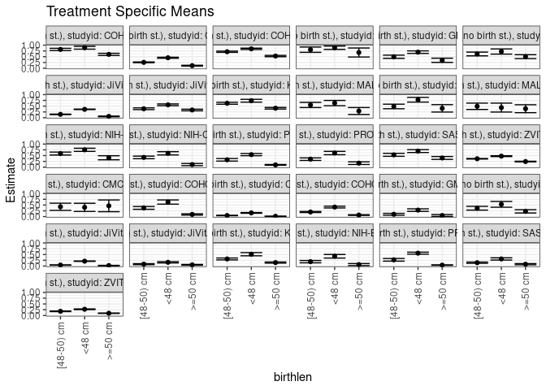

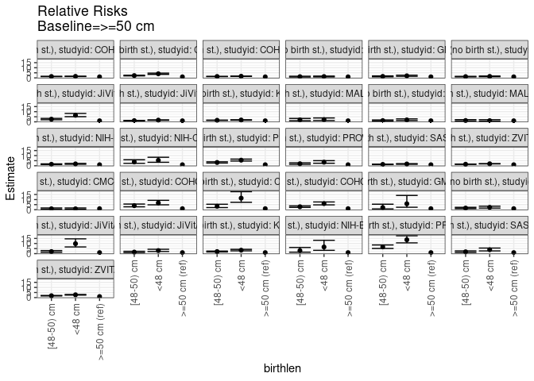

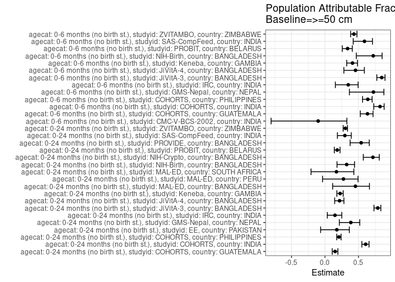

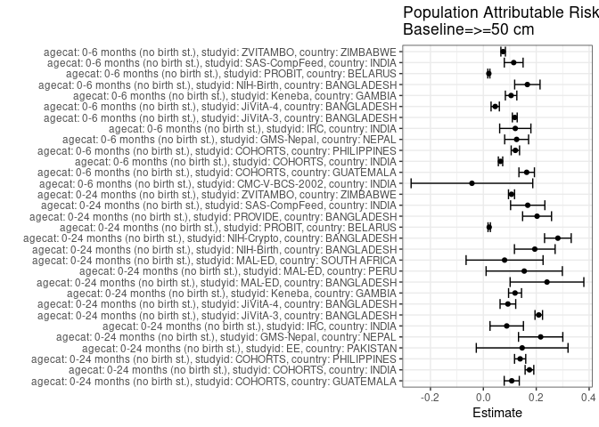

## Results Table

### Parameter: TSM

| agecat | studyid | country | intervention_level | baseline_level | estimate | ci_lower | ci_upper |
| --- | --- | --- | --- | --- | --- | --- | --- |
| 0-24 months (no birth st.) | COHORTS | GUATEMALA | >=50 cm | NA | 0.6008496 | 0.5547320 | 0.6469671 |
| 0-24 months (no birth st.) | COHORTS | GUATEMALA | <48 cm | NA | 0.8872887 | 0.8270110 | 0.9475664 |
| 0-24 months (no birth st.) | COHORTS | GUATEMALA | [48-50) cm | NA | 0.8144329 | 0.7657407 | 0.8631250 |
| 0-24 months (no birth st.) | COHORTS | INDIA | >=50 cm | NA | 0.1124418 | 0.0961130 | 0.1287706 |
| 0-24 months (no birth st.) | COHORTS | INDIA | <48 cm | NA | 0.4549257 | 0.4331424 | 0.4767091 |
| 0-24 months (no birth st.) | COHORTS | INDIA | [48-50) cm | NA | 0.2546393 | 0.2374373 | 0.2718412 |
| 0-24 months (no birth st.) | COHORTS | PHILIPPINES | >=50 cm | NA | 0.5280205 | 0.4995908 | 0.5564501 |
| 0-24 months (no birth st.) | COHORTS | PHILIPPINES | <48 cm | NA | 0.8413168 | 0.8123846 | 0.8702490 |
| 0-24 months (no birth st.) | COHORTS | PHILIPPINES | [48-50) cm | NA | 0.7156111 | 0.6898197 | 0.7414025 |
| 0-24 months (no birth st.) | EE | PAKISTAN | >=50 cm | NA | 0.6818182 | 0.4864898 | 0.8771466 |
| 0-24 months (no birth st.) | EE | PAKISTAN | <48 cm | NA | 0.8888889 | 0.8160370 | 0.9617408 |
| 0-24 months (no birth st.) | EE | PAKISTAN | [48-50) cm | NA | 0.8043478 | 0.6892969 | 0.9193987 |
| 0-24 months (no birth st.) | GMS-Nepal | NEPAL | >=50 cm | NA | 0.3450125 | 0.2533246 | 0.4367004 |
| 0-24 months (no birth st.) | GMS-Nepal | NEPAL | <48 cm | NA | 0.6967048 | 0.6410527 | 0.7523568 |
| 0-24 months (no birth st.) | GMS-Nepal | NEPAL | [48-50) cm | NA | 0.4978719 | 0.4293874 | 0.5663564 |
| 0-24 months (no birth st.) | IRC | INDIA | >=50 cm | NA | 0.5029232 | 0.4194966 | 0.5863498 |
| 0-24 months (no birth st.) | IRC | INDIA | <48 cm | NA | 0.7243380 | 0.6124413 | 0.8362346 |
| 0-24 months (no birth st.) | IRC | INDIA | [48-50) cm | NA | 0.6181692 | 0.5371308 | 0.6992076 |
| 0-24 months (no birth st.) | JiVitA-3 | BANGLADESH | >=50 cm | NA | 0.0560849 | 0.0422878 | 0.0698821 |
| 0-24 months (no birth st.) | JiVitA-3 | BANGLADESH | <48 cm | NA | 0.3628391 | 0.3515486 | 0.3741295 |
| 0-24 months (no birth st.) | JiVitA-3 | BANGLADESH | [48-50) cm | NA | 0.1456578 | 0.1347424 | 0.1565731 |
| 0-24 months (no birth st.) | JiVitA-4 | BANGLADESH | >=50 cm | NA | 0.3345782 | 0.3003676 | 0.3687888 |
| 0-24 months (no birth st.) | JiVitA-4 | BANGLADESH | <48 cm | NA | 0.5580135 | 0.5204450 | 0.5955821 |
| 0-24 months (no birth st.) | JiVitA-4 | BANGLADESH | [48-50) cm | NA | 0.3869490 | 0.3485048 | 0.4253932 |
| 0-24 months (no birth st.) | Keneba | GAMBIA | >=50 cm | NA | 0.4097480 | 0.3748355 | 0.4446606 |
| 0-24 months (no birth st.) | Keneba | GAMBIA | <48 cm | NA | 0.7352102 | 0.6737871 | 0.7966333 |
| 0-24 months (no birth st.) | Keneba | GAMBIA | [48-50) cm | NA | 0.6254188 | 0.5830746 | 0.6677629 |
| 0-24 months (no birth st.) | MAL-ED | BANGLADESH | >=50 cm | NA | 0.2887820 | 0.1386128 | 0.4389511 |
| 0-24 months (no birth st.) | MAL-ED | BANGLADESH | <48 cm | NA | 0.6339147 | 0.5200063 | 0.7478231 |
| 0-24 months (no birth st.) | MAL-ED | BANGLADESH | [48-50) cm | NA | 0.5512620 | 0.4389575 | 0.6635665 |

[output cut: 63 more lines]

### Parameter: E(Y)

| agecat | studyid | country | intervention_level | baseline_level | estimate | ci_lower | ci_upper |
| --- | --- | --- | --- | --- | --- | --- | --- |
| 0-24 months (no birth st.) | COHORTS | GUATEMALA | NA | NA | 0.7082294 | 0.6767491 | 0.7397098 |
| 0-24 months (no birth st.) | COHORTS | INDIA | NA | NA | 0.2867647 | 0.2751726 | 0.2983568 |
| 0-24 months (no birth st.) | COHORTS | PHILIPPINES | NA | NA | 0.6671324 | 0.6498678 | 0.6843969 |
| 0-24 months (no birth st.) | EE | PAKISTAN | NA | NA | 0.8285714 | 0.7659176 | 0.8912252 |
| 0-24 months (no birth st.) | GMS-Nepal | NEPAL | NA | NA | 0.5617391 | 0.5211485 | 0.6023298 |
| 0-24 months (no birth st.) | IRC | INDIA | NA | NA | 0.5913043 | 0.5393557 | 0.6432530 |
| 0-24 months (no birth st.) | JiVitA-3 | BANGLADESH | NA | NA | 0.2656094 | 0.2573816 | 0.2738373 |
| 0-24 months (no birth st.) | JiVitA-4 | BANGLADESH | NA | NA | 0.4273585 | 0.4069266 | 0.4477904 |
| 0-24 months (no birth st.) | Keneba | GAMBIA | NA | NA | 0.5296120 | 0.5040796 | 0.5551444 |
| 0-24 months (no birth st.) | MAL-ED | BANGLADESH | NA | NA | 0.5294118 | 0.4576804 | 0.6011431 |
| 0-24 months (no birth st.) | MAL-ED | PERU | NA | NA | 0.5603865 | 0.4926077 | 0.6281653 |
| 0-24 months (no birth st.) | MAL-ED | SOUTH AFRICA | NA | NA | 0.4690265 | 0.3766048 | 0.5614483 |
| 0-24 months (no birth st.) | NIH-Birth | BANGLADESH | NA | NA | 0.6007828 | 0.5582791 | 0.6432864 |
| 0-24 months (no birth st.) | NIH-Crypto | BANGLADESH | NA | NA | 0.3935681 | 0.3560687 | 0.4310676 |
| 0-24 months (no birth st.) | PROBIT | BELARUS | NA | NA | 0.1205488 | 0.1047261 | 0.1363714 |
| 0-24 months (no birth st.) | PROVIDE | BANGLADESH | NA | NA | 0.3759874 | 0.3382238 | 0.4137509 |
| 0-24 months (no birth st.) | SAS-CompFeed | INDIA | NA | NA | 0.5657407 | 0.5074689 | 0.6240126 |
| 0-24 months (no birth st.) | ZVITAMBO | ZIMBABWE | NA | NA | 0.3494034 | 0.3410405 | 0.3577663 |
| 0-6 months (no birth st.) | CMC-V-BCS-2002 | INDIA | NA | NA | 0.4235294 | 0.3178625 | 0.5291963 |
| 0-6 months (no birth st.) | COHORTS | GUATEMALA | NA | NA | 0.2581047 | 0.2278007 | 0.2884088 |
| 0-6 months (no birth st.) | COHORTS | INDIA | NA | NA | 0.0790014 | 0.0720874 | 0.0859154 |
| 0-6 months (no birth st.) | COHORTS | PHILIPPINES | NA | NA | 0.1893119 | 0.1749594 | 0.2036645 |
| 0-6 months (no birth st.) | GMS-Nepal | NEPAL | NA | NA | 0.1739130 | 0.1429052 | 0.2049209 |
| 0-6 months (no birth st.) | IRC | INDIA | NA | NA | 0.3478261 | 0.2974955 | 0.3981566 |
| 0-6 months (no birth st.) | JiVitA-3 | BANGLADESH | NA | NA | 0.1402030 | 0.1340165 | 0.1463895 |
| 0-6 months (no birth st.) | JiVitA-4 | BANGLADESH | NA | NA | 0.0984277 | 0.0855770 | 0.1112784 |
| 0-6 months (no birth st.) | Keneba | GAMBIA | NA | NA | 0.2552757 | 0.2329715 | 0.2775799 |
| 0-6 months (no birth st.) | NIH-Birth | BANGLADESH | NA | NA | 0.2309198 | 0.1943452 | 0.2674943 |
| 0-6 months (no birth st.) | PROBIT | BELARUS | NA | NA | 0.0614448 | 0.0507274 | 0.0721623 |
| 0-6 months (no birth st.) | SAS-CompFeed | INDIA | NA | NA | 0.1946247 | 0.1703263 | 0.2189230 |
| 0-6 months (no birth st.) | ZVITAMBO | ZIMBABWE | NA | NA | 0.1729137 | 0.1662801 | 0.1795472 |

### Parameter: RR

| agecat | studyid | country | intervention_level | baseline_level | estimate | ci_lower | ci_upper |
| --- | --- | --- | --- | --- | --- | --- | --- |
| 0-24 months (no birth st.) | COHORTS | GUATEMALA | >=50 cm | >=50 cm | 1.0000000 | 1.0000000 | 1.000000 |
| 0-24 months (no birth st.) | COHORTS | GUATEMALA | <48 cm | >=50 cm | 1.4767235 | 1.3327880 | 1.636203 |
| 0-24 months (no birth st.) | COHORTS | GUATEMALA | [48-50) cm | >=50 cm | 1.3554688 | 1.2297190 | 1.494078 |
| 0-24 months (no birth st.) | COHORTS | INDIA | >=50 cm | >=50 cm | 1.0000000 | 1.0000000 | 1.000000 |
| 0-24 months (no birth st.) | COHORTS | INDIA | <48 cm | >=50 cm | 4.0458772 | 3.4743833 | 4.711375 |
| 0-24 months (no birth st.) | COHORTS | INDIA | [48-50) cm | >=50 cm | 2.2646315 | 1.9316717 | 2.654983 |
| 0-24 months (no birth st.) | COHORTS | PHILIPPINES | >=50 cm | >=50 cm | 1.0000000 | 1.0000000 | 1.000000 |
| 0-24 months (no birth st.) | COHORTS | PHILIPPINES | <48 cm | >=50 cm | 1.5933413 | 1.4956801 | 1.697379 |
| 0-24 months (no birth st.) | COHORTS | PHILIPPINES | [48-50) cm | >=50 cm | 1.3552716 | 1.2714525 | 1.444616 |
| 0-24 months (no birth st.) | EE | PAKISTAN | >=50 cm | >=50 cm | 1.0000000 | 1.0000000 | 1.000000 |
| 0-24 months (no birth st.) | EE | PAKISTAN | <48 cm | >=50 cm | 1.3037037 | 0.9677655 | 1.756255 |
| 0-24 months (no birth st.) | EE | PAKISTAN | [48-50) cm | >=50 cm | 1.1797101 | 0.8564700 | 1.624944 |
| 0-24 months (no birth st.) | GMS-Nepal | NEPAL | >=50 cm | >=50 cm | 1.0000000 | 1.0000000 | 1.000000 |
| 0-24 months (no birth st.) | GMS-Nepal | NEPAL | <48 cm | >=50 cm | 2.0193612 | 1.5305523 | 2.664280 |
| 0-24 months (no birth st.) | GMS-Nepal | NEPAL | [48-50) cm | >=50 cm | 1.4430549 | 1.0702113 | 1.945791 |
| 0-24 months (no birth st.) | IRC | INDIA | >=50 cm | >=50 cm | 1.0000000 | 1.0000000 | 1.000000 |
| 0-24 months (no birth st.) | IRC | INDIA | <48 cm | >=50 cm | 1.4402556 | 1.1481031 | 1.806751 |
| 0-24 months (no birth st.) | IRC | INDIA | [48-50) cm | >=50 cm | 1.2291524 | 0.9954767 | 1.517680 |
| 0-24 months (no birth st.) | JiVitA-3 | BANGLADESH | >=50 cm | >=50 cm | 1.0000000 | 1.0000000 | 1.000000 |
| 0-24 months (no birth st.) | JiVitA-3 | BANGLADESH | <48 cm | >=50 cm | 6.4694575 | 5.0652797 | 8.262896 |
| 0-24 months (no birth st.) | JiVitA-3 | BANGLADESH | [48-50) cm | >=50 cm | 2.5970929 | 2.0131569 | 3.350405 |
| 0-24 months (no birth st.) | JiVitA-4 | BANGLADESH | >=50 cm | >=50 cm | 1.0000000 | 1.0000000 | 1.000000 |
| 0-24 months (no birth st.) | JiVitA-4 | BANGLADESH | <48 cm | >=50 cm | 1.6678119 | 1.4749555 | 1.885885 |
| 0-24 months (no birth st.) | JiVitA-4 | BANGLADESH | [48-50) cm | >=50 cm | 1.1565278 | 1.0004028 | 1.337018 |
| 0-24 months (no birth st.) | Keneba | GAMBIA | >=50 cm | >=50 cm | 1.0000000 | 1.0000000 | 1.000000 |
| 0-24 months (no birth st.) | Keneba | GAMBIA | <48 cm | >=50 cm | 1.7942983 | 1.5930781 | 2.020934 |
| 0-24 months (no birth st.) | Keneba | GAMBIA | [48-50) cm | >=50 cm | 1.5263496 | 1.3702447 | 1.700239 |
| 0-24 months (no birth st.) | MAL-ED | BANGLADESH | >=50 cm | >=50 cm | 1.0000000 | 1.0000000 | 1.000000 |
| 0-24 months (no birth st.) | MAL-ED | BANGLADESH | <48 cm | >=50 cm | 2.1951324 | 1.2643286 | 3.811198 |
| 0-24 months (no birth st.) | MAL-ED | BANGLADESH | [48-50) cm | >=50 cm | 1.9089209 | 1.0913402 | 3.338995 |

[output cut: 63 more lines]

### Parameter: PAR

| agecat | studyid | country | intervention_level | baseline_level | estimate | ci_lower | ci_upper |
| --- | --- | --- | --- | --- | --- | --- | --- |
| 0-24 months (no birth st.) | COHORTS | GUATEMALA | >=50 cm | NA | 0.1073799 | 0.0788734 | 0.1358863 |
| 0-24 months (no birth st.) | COHORTS | INDIA | >=50 cm | NA | 0.1743229 | 0.1579311 | 0.1907147 |
| 0-24 months (no birth st.) | COHORTS | PHILIPPINES | >=50 cm | NA | 0.1391119 | 0.1179409 | 0.1602830 |
| 0-24 months (no birth st.) | EE | PAKISTAN | >=50 cm | NA | 0.1467532 | -0.0267047 | 0.3202112 |
| 0-24 months (no birth st.) | GMS-Nepal | NEPAL | >=50 cm | NA | 0.2167267 | 0.1329606 | 0.3004927 |
| 0-24 months (no birth st.) | IRC | INDIA | >=50 cm | NA | 0.0883812 | 0.0251863 | 0.1515760 |
| 0-24 months (no birth st.) | JiVitA-3 | BANGLADESH | >=50 cm | NA | 0.2095245 | 0.1952762 | 0.2237728 |
| 0-24 months (no birth st.) | JiVitA-4 | BANGLADESH | >=50 cm | NA | 0.0927803 | 0.0631860 | 0.1223745 |
| 0-24 months (no birth st.) | Keneba | GAMBIA | >=50 cm | NA | 0.1198639 | 0.0953513 | 0.1443766 |
| 0-24 months (no birth st.) | MAL-ED | BANGLADESH | >=50 cm | NA | 0.2406298 | 0.1012485 | 0.3800110 |
| 0-24 months (no birth st.) | MAL-ED | PERU | >=50 cm | NA | 0.1545942 | 0.0103897 | 0.2987987 |
| 0-24 months (no birth st.) | MAL-ED | SOUTH AFRICA | >=50 cm | NA | 0.0802693 | -0.0652829 | 0.2258214 |
| 0-24 months (no birth st.) | NIH-Birth | BANGLADESH | >=50 cm | NA | 0.1944734 | 0.1175544 | 0.2713925 |
| 0-24 months (no birth st.) | NIH-Crypto | BANGLADESH | >=50 cm | NA | 0.2818030 | 0.2314134 | 0.3321926 |
| 0-24 months (no birth st.) | PROBIT | BELARUS | >=50 cm | NA | 0.0221040 | 0.0176521 | 0.0265558 |
| 0-24 months (no birth st.) | PROVIDE | BANGLADESH | >=50 cm | NA | 0.2031271 | 0.1484268 | 0.2578273 |
| 0-24 months (no birth st.) | SAS-CompFeed | INDIA | >=50 cm | NA | 0.1677919 | 0.1030041 | 0.2325797 |
| 0-24 months (no birth st.) | ZVITAMBO | ZIMBABWE | >=50 cm | NA | 0.1065228 | 0.0950793 | 0.1179663 |
| 0-6 months (no birth st.) | CMC-V-BCS-2002 | INDIA | >=50 cm | NA | -0.0431373 | -0.2731369 | 0.1868624 |
| 0-6 months (no birth st.) | COHORTS | GUATEMALA | >=50 cm | NA | 0.1638005 | 0.1345284 | 0.1930725 |
| 0-6 months (no birth st.) | COHORTS | INDIA | >=50 cm | NA | 0.0649456 | 0.0567516 | 0.0731395 |
| 0-6 months (no birth st.) | COHORTS | PHILIPPINES | >=50 cm | NA | 0.1210402 | 0.1052402 | 0.1368402 |
| 0-6 months (no birth st.) | GMS-Nepal | NEPAL | >=50 cm | NA | 0.1258361 | 0.0806442 | 0.1710280 |
| 0-6 months (no birth st.) | IRC | INDIA | >=50 cm | NA | 0.1207382 | 0.0616962 | 0.1797801 |
| 0-6 months (no birth st.) | JiVitA-3 | BANGLADESH | >=50 cm | NA | 0.1187570 | 0.1095949 | 0.1279190 |
| 0-6 months (no birth st.) | JiVitA-4 | BANGLADESH | >=50 cm | NA | 0.0448764 | 0.0292179 | 0.0605349 |
| 0-6 months (no birth st.) | Keneba | GAMBIA | >=50 cm | NA | 0.1048958 | 0.0832039 | 0.1265877 |
| 0-6 months (no birth st.) | NIH-Birth | BANGLADESH | >=50 cm | NA | 0.1664036 | 0.1184256 | 0.2143817 |
| 0-6 months (no birth st.) | PROBIT | BELARUS | >=50 cm | NA | 0.0207517 | 0.0167777 | 0.0247258 |
| 0-6 months (no birth st.) | SAS-CompFeed | INDIA | >=50 cm | NA | 0.1147599 | 0.0792509 | 0.1502690 |
| 0-6 months (no birth st.) | ZVITAMBO | ZIMBABWE | >=50 cm | NA | 0.0747910 | 0.0662673 | 0.0833148 |

### Parameter: PAF

| agecat | studyid | country | intervention_level | baseline_level | estimate | ci_lower | ci_upper |
| --- | --- | --- | --- | --- | --- | --- | --- |
| 0-24 months (no birth st.) | COHORTS | GUATEMALA | >=50 cm | NA | 0.1516173 | 0.1085703 | 0.1925856 |
| 0-24 months (no birth st.) | COHORTS | INDIA | >=50 cm | NA | 0.6078952 | 0.5505693 | 0.6579091 |
| 0-24 months (no birth st.) | COHORTS | PHILIPPINES | >=50 cm | NA | 0.2085222 | 0.1752021 | 0.2404962 |
| 0-24 months (no birth st.) | EE | PAKISTAN | >=50 cm | NA | 0.1771160 | -0.0650910 | 0.3642439 |
| 0-24 months (no birth st.) | GMS-Nepal | NEPAL | >=50 cm | NA | 0.3858137 | 0.2150660 | 0.5194185 |
| 0-24 months (no birth st.) | IRC | INDIA | >=50 cm | NA | 0.1494681 | 0.0340759 | 0.2510752 |
| 0-24 months (no birth st.) | JiVitA-3 | BANGLADESH | >=50 cm | NA | 0.7888444 | 0.7314664 | 0.8339623 |
| 0-24 months (no birth st.) | JiVitA-4 | BANGLADESH | >=50 cm | NA | 0.2171017 | 0.1450009 | 0.2831225 |
| 0-24 months (no birth st.) | Keneba | GAMBIA | >=50 cm | NA | 0.2263241 | 0.1775860 | 0.2721738 |
| 0-24 months (no birth st.) | MAL-ED | BANGLADESH | >=50 cm | NA | 0.4545229 | 0.1145472 | 0.6639626 |
| 0-24 months (no birth st.) | MAL-ED | PERU | >=50 cm | NA | 0.2758707 | -0.0367526 | 0.4942252 |
| 0-24 months (no birth st.) | MAL-ED | SOUTH AFRICA | >=50 cm | NA | 0.1711401 | -0.2079638 | 0.4312672 |
| 0-24 months (no birth st.) | NIH-Birth | BANGLADESH | >=50 cm | NA | 0.3237001 | 0.1801294 | 0.4421296 |
| 0-24 months (no birth st.) | NIH-Crypto | BANGLADESH | >=50 cm | NA | 0.7160209 | 0.5724293 | 0.8113899 |
| 0-24 months (no birth st.) | PROBIT | BELARUS | >=50 cm | NA | 0.1833611 | 0.1392330 | 0.2252269 |
| 0-24 months (no birth st.) | PROVIDE | BANGLADESH | >=50 cm | NA | 0.5402497 | 0.3751833 | 0.6617082 |
| 0-24 months (no birth st.) | SAS-CompFeed | INDIA | >=50 cm | NA | 0.2965880 | 0.1855693 | 0.3924733 |
| 0-24 months (no birth st.) | ZVITAMBO | ZIMBABWE | >=50 cm | NA | 0.3048705 | 0.2715202 | 0.3366941 |
| 0-6 months (no birth st.) | CMC-V-BCS-2002 | INDIA | >=50 cm | NA | -0.1018519 | -0.8043179 | 0.3271266 |
| 0-6 months (no birth st.) | COHORTS | GUATEMALA | >=50 cm | NA | 0.6346279 | 0.5274261 | 0.7175113 |
| 0-6 months (no birth st.) | COHORTS | INDIA | >=50 cm | NA | 0.8220814 | 0.7282020 | 0.8835348 |
| 0-6 months (no birth st.) | COHORTS | PHILIPPINES | >=50 cm | NA | 0.6393690 | 0.5603337 | 0.7041968 |
| 0-6 months (no birth st.) | GMS-Nepal | NEPAL | >=50 cm | NA | 0.7235577 | 0.3651686 | 0.8796210 |
| 0-6 months (no birth st.) | IRC | INDIA | >=50 cm | NA | 0.3471222 | 0.1550903 | 0.4955089 |
| 0-6 months (no birth st.) | JiVitA-3 | BANGLADESH | >=50 cm | NA | 0.8470358 | 0.7739804 | 0.8964777 |
| 0-6 months (no birth st.) | JiVitA-4 | BANGLADESH | >=50 cm | NA | 0.4559331 | 0.2821390 | 0.5876517 |
| 0-6 months (no birth st.) | Keneba | GAMBIA | >=50 cm | NA | 0.4109117 | 0.3245248 | 0.4862505 |
| 0-6 months (no birth st.) | NIH-Birth | BANGLADESH | >=50 cm | NA | 0.7206124 | 0.4682685 | 0.8532014 |
| 0-6 months (no birth st.) | PROBIT | BELARUS | >=50 cm | NA | 0.3377295 | 0.2587100 | 0.4083257 |
| 0-6 months (no birth st.) | SAS-CompFeed | INDIA | >=50 cm | NA | 0.5896475 | 0.4214667 | 0.7089378 |
| 0-6 months (no birth st.) | ZVITAMBO | ZIMBABWE | >=50 cm | NA | 0.4325339 | 0.3832586 | 0.4778723 |